# **GR5242 Advanced Machine Learning**

## **Homework 3**

## **Name: Yi-Pei Chan** **UNI: yc3700**

## 1. Compare DBScan and MeanShift

The DBSCAN function uses two parameters eps and min samples. The first parameter eps corresponds to the bandwidth parameter h, in the course notes. The second parameter min samples min samples is proportional to the level λ from the course notes. More precisely, we have

λ = min_samples / Vol(B(0,h))

Make appropriate choices of these parameters as follows.

• Set eps to be 20% quantile of interpoint distances when using DBSCAN, and same setting as for MeanShift

• For minsamples in the range [100,400,700,1000], pick the smallest value that gives more than one cluster

```python
import numpy as np
from IPython.display import Image
from sklearn.cluster import KMeans
from sklearn.metrics.cluster import adjusted_rand_score
import matplotlib.pyplot as plt
from sklearn.decomposition import PCA
from sklearn.cluster import DBSCAN
```

```python
# Problem 8
from sklearn.cluster import MeanShift , KMeans , SpectralClustering, estimate_bandwidth

import random
import math
random.seed(0)


##Data set 1
X1 = []
for i in range(1000):
  theta = random.uniform(0,2*math.pi)
  radius = random.gauss(0,0.2)+random.choice([1,3])
  X1.append([radius*math.cos(theta),radius*math.sin(theta)])
X1 = np.array(X1)

##Data Set 2
X2 = []
for i in range(1000):
  theta = random.uniform(0,2*math.pi)
  radius = random.gauss(0,0.1) + 2
  if theta<math.pi:
    X2.append([radius*math.cos(theta)-1,radius*math.sin(theta)])
  else:
    X2.append([radius*math.cos(theta)+1,radius*math.sin(theta)])
X2 = np.array(X2)


##Data Set 3
X3 = []
for i in range(1000):
  radius = random.gauss(0,1)
  theta = random.uniform(0,2*math.pi)
  center = random.choice([[0,1],[3,3],[1,-3]])
  X3.append([radius*math.cos(theta)+center[0],radius*math.sin(theta)+center[1]])

X3 = np.array(X3)
```

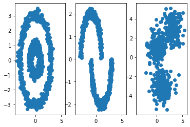

```python
fig, axs = plt.subplots(nrows=1, ncols=3, sharex=True)
ax = axs[0]
ax.scatter(X1[:,0],X1[:,1])
ax = axs[1]
ax.scatter(X2[:,0],X2[:,1])
ax = axs[2]
ax.scatter(X3[:,0],X3[:,1])
```

### (a) Plot the results of the clustering obtained using DBSCAN

```python
lamb = [100, 400, 700, 1000]
```

```python
bandwidth1 = estimate_bandwidth(X1, quantile=0.2)
bandwidth2 = estimate_bandwidth(X2, quantile=0.2)
bandwidth3 = estimate_bandwidth(X3, quantile=0.2)

#db0 = DBSCAN(eps=bandwidth1, min_samples= 100).fit(X1)
#db0 does not work well

db1 = DBSCAN(eps=bandwidth1, min_samples= 400).fit(X1)
db2 = DBSCAN(eps=bandwidth2, min_samples= 100).fit(X2)
db3 = DBSCAN(eps=bandwidth3, min_samples= 100).fit(X3)
```

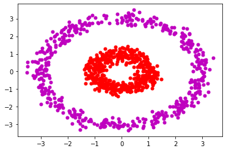

```python
label_pred = db1.labels_
mark = ['or', 'ob', 'oy', 'g','c','m','k','om']
j=0
for i in label_pred:
  plt.plot([X1[j:j+1,0]], [X1[j:j+1,1]], mark[i], markersize = 5)
  j +=1
plt.show()
```

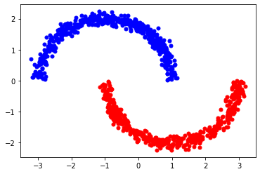

```python
label_pred = db2.labels_
mark = ['or', 'ob', 'oy', 'g','c','m','k','om']
j=0
for i in label_pred:
  plt.plot([X2[j:j+1,0]], [X2[j:j+1,1]], mark[i], markersize = 5)
  j +=1
plt.show()
```

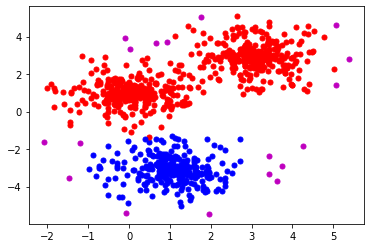

```python
label_pred = db3.labels_
mark = ['or', 'ob', 'oy', 'g','c','m','k','om']
j=0
for i in label_pred:
  plt.plot([X3[j:j+1,0]], [X3[j:j+1,1]], mark[i], markersize = 5)
  j +=1
plt.show()
```

### (b) Plot the results of clustering using MeanShift

```python
bandwidth1 = estimate_bandwidth(X1, quantile=0.2)
bandwidth2 = estimate_bandwidth(X2, quantile=0.2)
bandwidth3 = estimate_bandwidth(X3, quantile=0.2)


clustering1 = MeanShift(bandwidth=bandwidth1).fit(X1)
clustering2 = MeanShift(bandwidth=bandwidth2).fit(X2)
clustering3 = MeanShift(bandwidth=bandwidth3).fit(X3)
#clustering1.labels_
```

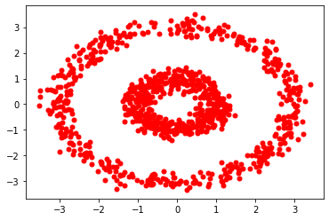

```python
label_pred = clustering1.labels_
mark = ['or', 'ob', 'oy', 'g','c','m','k','w']
j=0
for i in label_pred:
  plt.plot([X1[j:j+1,0]], [X1[j:j+1,1]], mark[i], markersize = 5)
  j +=1
plt.show()
```

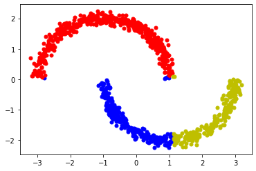

```python
label_pred = clustering2.labels_
mark = ['or', 'ob', 'oy', 'g','c','m','k','w']
j=0
for i in label_pred:
  plt.plot([X2[j:j+1,0]], [X2[j:j+1,1]], mark[i], markersize = 5)
  j +=1
plt.show()
```

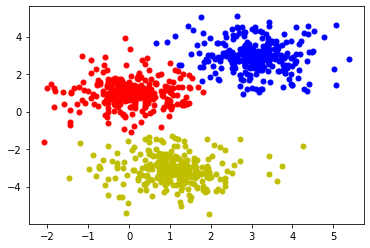

```python
label_pred = clustering3.labels_
mark = ['or', 'ob', 'oy', 'g','c','m','k','w']
j=0
for i in label_pred:
  plt.plot([X3[j:j+1,0]], [X3[j:j+1,1]], mark[i], markersize = 5)
  j +=1
plt.show()
```

### (c) DBSCAN should vastly outperform MeanShift on at least 2 of the datasets? Which 2 datasets? Give a simple explanation as to why DBSCAN might do better there.

The DBSCAN outperforms the MeanShift on the first 2 datasets. DBSCAN performs better on the first 2 dataset, because It identifies outliers as noises, unlike mean-shift which detects clusters based on euclidean distances and assign points to the nearest mode.

The main drawback of DBSCAN is that it doesn’t perform as well as others when the clusters are of varying density. This is because the setting of the distance threshold ε and minPoints for identifying the neighborhood points will vary from cluster to cluster when the density varies. This drawback also occurs with very high-dimensional data since again the distance threshold ε becomes challenging to estimate.

## 2. Compare Adam & Adagrad

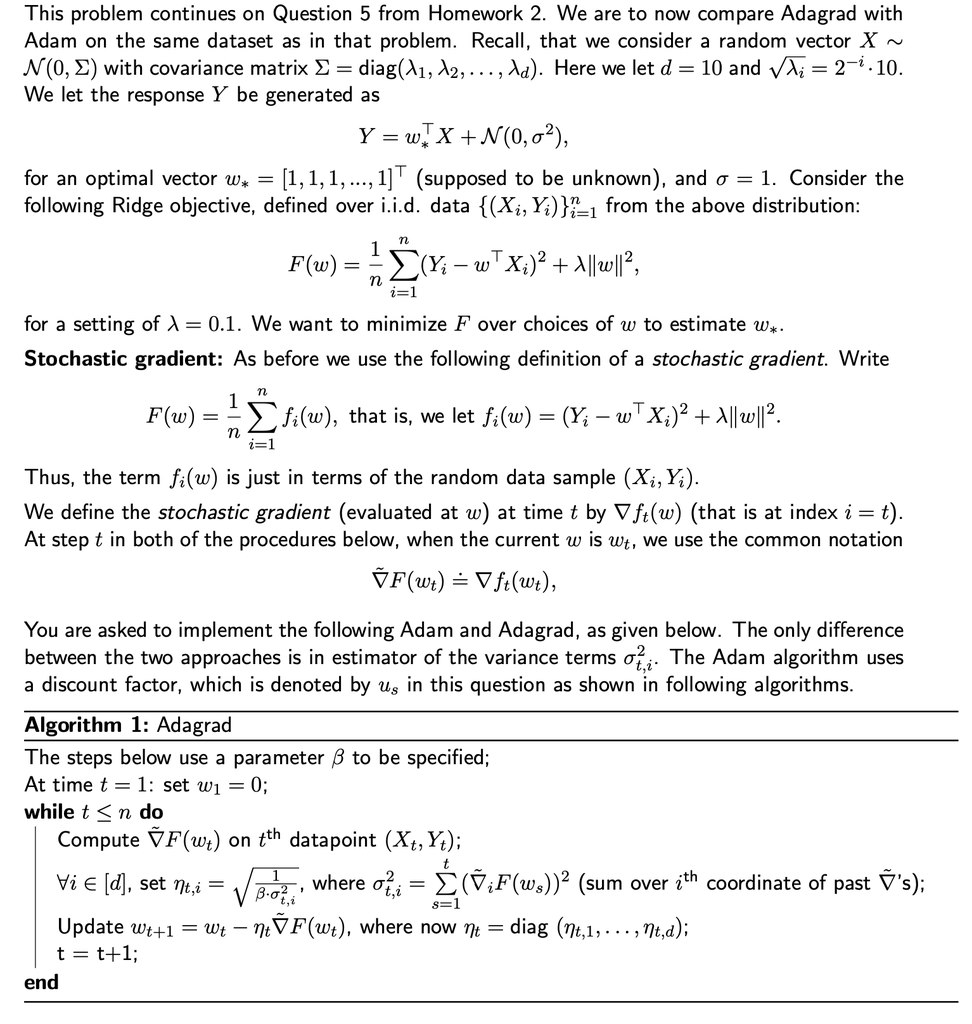

```python
Image(filename = "Adagrad.png", width = 1000, height = 800)
```

```python
#Data sampler code:
## Code for generator/sampler
import numpy as np
import random
import time
from numpy import linalg as LA
import statistics #initialization

sigma = 1
d = 10
c_square = 100
cov = np.diag([(0.25**i)*c_square for i in range(1,d+1)])
mean = [0]*d

#coeficient given
w = np.array([1]*d)

# Sampler function
def sampler(n):
    #data X generator
    np.random.seed(int(time.time()*100000)%100000)
    X = np.random.multivariate_normal(mean, cov, n)

    #data Y generator
    Y = np.matmul(X, w)+np.random.normal(0, sigma**2, n)
    return (X,Y)
```

```python
x,y =sampler(1)
print("x = ", x)
print("\ny = ", y)
```

```
x =  [[-4.32863095 -0.03094084 -1.7393849  -0.3431296   0.1791765  -0.00694962
  -0.22263504 -0.03004764 -0.0174138  -0.00835146]]

y =  [-7.65080219]
```

```python
## Adagrad
lambda_given = 0.1
lambda1 = ((2**-1) * 10)**2
beta = 2 * (lambda1 + 0.1) #(0.25*c_square+lambda_given)
T = 1000

def Adagrad(data, T):
    X = data[0]
    Y = data[1]
    w1 = np.array([0]*d)
    w_path = [w1]
    cumu_derivative_square = 0
    for t in range(T):
        deriv = 2 * ( np.matmul(data[0][t],w1) * data[0][t] + 0.1 * w1 - data[1][t] * data[0][t])
        cumu_derivative_square += deriv**2
        ita = (1 / ( beta * cumu_derivative_square))**(0.5)
        w1 = w1 - ita * deriv
        w_path.append(w1)
    return w_path
```

```python
## implement and take average of distances
random.seed(1)
w_all_ada = []
for i in range(10):
    data = sampler(T)
    print(Adagrad(data, T)[-1])
    w_all_ada.append(Adagrad(data, T))

Adagrad_distance = []
Adagrad_std = []
for t in range(T):
    distances = []
    for i in range(10):
        distances.append(LA.norm(w-w_all_ada[i][t]))
    Adagrad_distance.append(sum(distances)/10)
    Adagrad_std.append(statistics.stdev(distances))
```

```
[ 1.00062863  1.03353581  0.96628989  0.72407901  0.40679514  0.15999205
  0.06997547 -0.01949524 -0.00593843 -0.00374281]
[ 1.00539017  0.94224247  0.95348977  0.77416155  0.46594805  0.15321123
  0.08856574  0.03863784 -0.01992269 -0.0139412 ]
[ 0.96962177  0.99472166  0.87602893  0.80843544  0.46568456  0.16274683
  0.04194225  0.03222652 -0.01111813  0.00264326]
[ 1.00355815  1.02169749  0.91611963  0.82340214  0.45945404  0.14895401
  0.09845093  0.00150986 -0.02873992 -0.02082247]
[ 1.01113744  0.98506312  0.90685826  0.69780272  0.53714837  0.3039067
  0.08355969  0.00805005  0.03871123 -0.00859617]
[ 1.03393842  0.99359195  0.95106541  0.82476514  0.54799961  0.2314897
  0.06412871 -0.0365659   0.00460322 -0.00891648]
[ 1.00468191  0.94974185  0.91417966  0.80979305  0.48780873  0.25516102
  0.0643046   0.0167702  -0.0213549   0.00523328]
[ 1.00042174  0.96942838  0.92180261  0.7863841   0.44073536  0.14560948
  0.06873066 -0.00528078  0.01942451  0.01373345]
[ 0.98223038  0.93541644  0.95882747  0.8756987   0.52528349  0.24919026
  0.13196043  0.02152904  0.01386822 -0.00159157]
[ 0.99030089  0.9778623   0.94029372  0.89700672  0.51070852  0.23024383
  0.11934675 -0.03655228 -0.0443479  -0.02122005]
```

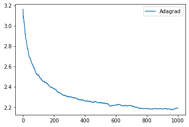

```python
plt.plot(Adagrad_distance,label='Adagrad')
plt.legend()
plt.show()
```

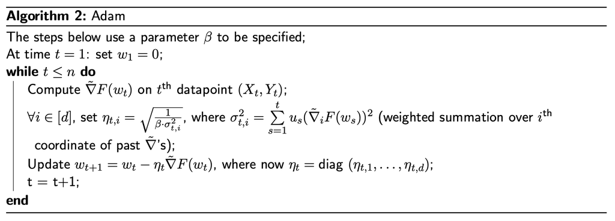

```python
Image(filename = "adam.png", width = 800, height = 500)
```

```python
lambda_given = 0.1
lambda1 = ((2**-1) * 10)**2
beta = 2 * (lambda1 + 0.1) #(0.25*c_square+lambda_given)
T = 1000
```

```python
exp_factor = 1.1
def Adam(data):
    X = data[0]
    Y = data[1]
    w1 = np.array([0]*d)
    w_path = [w1]
    cumu_derivative_square = 0
    for t in range(T):
        deriv = 2*(np.matmul(data[0][t],w1)*data[0][t]+lambda_given*w1-data[1][t]*data[0][t])
        cumu_derivative_square = cumu_derivative_square / exp_factor + (deriv**2)
        ita = (1/(2*(0.25*c_square+lambda_given)*(1+t)*(1-1/exp_factor)/(1-(1/exp_factor)**(t+2))*cumu_derivative_square))**(0.5)
        w1=w1-ita*deriv
        w_path.append(w1)
    return w_path
```

```python
np.random.seed(1)
adam_w_all = []
for i in range(10):
    data = sampler(T)
    adam_w_all.append(Adam(data))

Adam_distance = []
Adam_std = []
for t in range(T):
    distances = []
    for i in range(10):
        distances.append(LA.norm(w-adam_w_all[i][t]))
    Adam_distance.append(sum(distances)/10)
    Adam_std.append(statistics.stdev(distances))
```

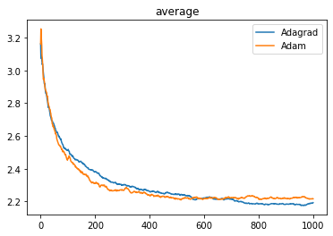

```python
plt.plot(Adagrad_distance,label='Adagrad')
plt.plot(Adam_distance,label='Adam')
plt.title("average")
plt.legend()
plt.show()
```

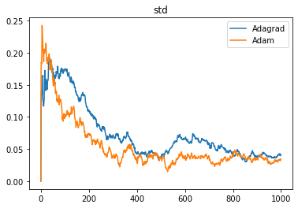

```python
plt.plot(Adagrad_std,label='Adagrad')
plt.plot(Adam_std,label='Adam')
plt.title("std")
plt.legend()
plt.show()
```

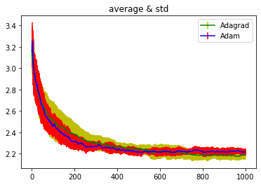

```python
plt.errorbar(list(range(0,T)), Adagrad_distance, yerr = Adagrad_std, fmt='g', ecolor='y', label='Adagrad')
plt.errorbar(list(range(0,T)), Adam_distance, yerr = Adam_std, fmt='b', ecolor='r',label='Adam')
plt.title("average & std")
plt.legend()
plt.show()
```

### (b) Why should it be the case that Adam’s estimation σ^2_t,i of the gradient variance terms, i.e., through a discounting factor, might be better than that of Adagrad? In other words, what problem is Adam fixing? (Try to be clear but brief).

Adam solve the denominator decay problem of AdaGrad by using a discount factor. AdaGrad shrinks the learning rate very aggressively, i.e. it decays the learning rate for parameters in proportion to their update history (more updates means more decay). Therefore, after a while, the frequent parameters will start receiving very small updates because of the decayed learning rate.

## 3. Bias and Variance

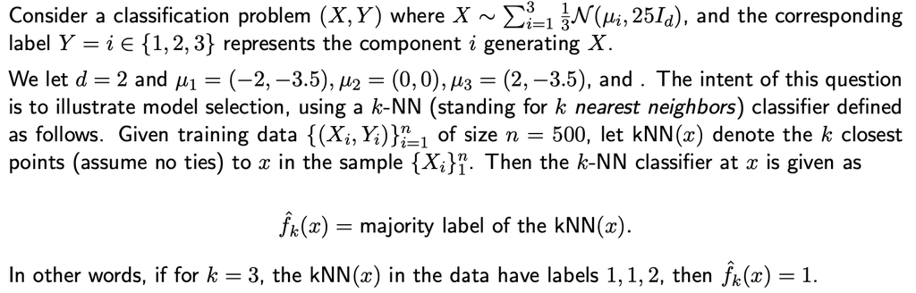

```python
import random
import numpy as np
d=2
mu0 = [[-2,-3.5],[0,0],[2,-3.5]]
Id = [[25,0],[0,25]]
n=500

def Data_Generate(n):
    outX = []
    outY = np.random.choice(list(range(3)),n,replace = True, p = [0.5,0.25,0.25])
    for i in range(n):
        mu = mu0[outY[i]]
        X = np.random.multivariate_normal(mu,Id,1)[0].tolist()
        outX.append(X)
    return outX,outY
```

### (a) For the largest possible choice of k = n

When k=n, the model is stable but poor, because every datapoint in the dataset is considered to be within the same neighborhood. In this problem, when k = n, the model would be constant over all x, because we are taking the majority label of all the datapoints in the dataset, instead of only considering certain numbers of closest members. In general a larger k suppresses the effects of noise, but makes the classification boundaries less distinct.

### (b) Draw and fix a test sample (X'i, Y'i) of the same size n

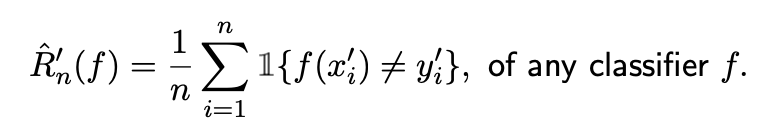

```python
Image(filename = "testerror.png", width = 400, height = 300)
```

```python
from sklearn.neighbors import KNeighborsClassifier
testX, testY = Data_Generate(n)
```

```python
# according to instructors ans on piazza
k = list(range(1,500, 50))
print(k)
```

```
[1, 51, 101, 151, 201, 251, 301, 351, 401, 451]
```

```python
k = list(range(1,500, 50)) #list(range(1,500, 50))

def test_error(x,y):
    count = 0
    for i in range(len(y)):
        if x[i] != y[i] :  count += 1

    count /= len(y)

    return count

errorlist = np.zeros((len(k),10))

for j in range(len(k)):
    error = 0
    for i in range(10):
        trainX , trainY = Data_Generate(n)
        ENN = KNeighborsClassifier(n_neighbors = k[j])
        ENN.fit(trainX , trainY)
        errorlist[j][i] = test_error(ENN.predict(testX), testY)

print(errorlist)
```

```
[[0.604 0.58  0.57  0.568 0.58  0.584 0.562 0.57  0.564 0.602]
 [0.464 0.43  0.478 0.458 0.472 0.502 0.448 0.448 0.424 0.486]
 [0.46  0.442 0.46  0.446 0.446 0.452 0.45  0.454 0.46  0.444]
 [0.476 0.452 0.468 0.446 0.442 0.46  0.476 0.45  0.432 0.458]
 [0.448 0.468 0.46  0.456 0.44  0.456 0.48  0.452 0.478 0.46 ]
 [0.482 0.47  0.466 0.48  0.48  0.48  0.47  0.48  0.48  0.456]
 [0.48  0.48  0.48  0.48  0.48  0.48  0.48  0.48  0.48  0.48 ]
 [0.48  0.48  0.48  0.48  0.48  0.48  0.48  0.48  0.48  0.48 ]
 [0.48  0.48  0.48  0.48  0.48  0.48  0.48  0.48  0.48  0.48 ]
 [0.48  0.48  0.48  0.48  0.48  0.48  0.48  0.48  0.48  0.48 ]]
```

```python
average = list(map(lambda x: np.mean(errorlist[x,:]),list(range(len(k)))))
std = list(map(lambda x: np.std(errorlist[x,:]),list(range(len(k)))))
#print(average, np.mean(errorlist[0,]),std, np.std(errorlist[0,]))
#print(std)
```

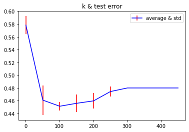

```python
plt.errorbar(k, average, yerr = std, fmt='b', ecolor='r',label='average & std')
plt.title("k & test error")
plt.legend()
plt.show()
```

### (c) For which values of k do we observe higher variances? That is, for the smaller or higher values? Explain why in terms of the ability of fk to fit general functions

```python
print(max(std))
place = np.where(std == max(std))[0]
#std[place]
print(place , k[place[0]], std[place[0]])
```

```
0.023242202993692312
[1] 51 0.023242202993692312
```